# Itô's Formula: Correction, Martingales, and Quadratic Variation

## 1. The Itô correction

For $f\in C^2(\mathbb R)$, Theorem 5.1 states that, for every $t\geq0$,

$$ f(B_t)-f(0) =\int_0^t f'(B_s)\,dB_s +\frac{1}{2}\int_0^t f''(B_s)\,ds. $$

The second-order term remains because squared Brownian increments accumulate rather than disappear. For $f(x)=\sin x$, the two uniform-grid sums used below are

$$ S_k^{\mathrm{naive}} =\sum_{i<k}\cos(B_{t_i})\Delta B_i, \qquad S_k^{\mathrm{corr}} =\sum_{i<k}\left[ \cos(B_{t_i})\Delta B_i-\frac{1}{2}\sin(B_{t_i})\Delta t \right]. $$

Both use left-endpoint information. The exact transformed path at the grid points is $\sin(B_{t_k})$.

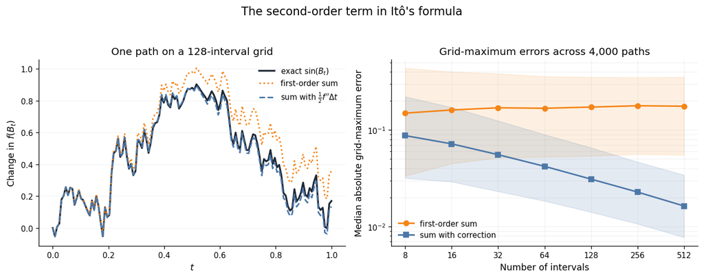

**Figure 1.** First-order and Itô-corrected sums for $f(x)=\sin x$, with central 80% error bands across 4,000 paths.

Interpretation. On the displayed path, the first-order sum separates from $\sin(B_t)$, while the corrected sum follows it closely. Across simulated paths, refinement contracts the corrected grid-maximum error but does not remove the omitted second-order contribution from the naive sum. Theorem 5.1 supplies the identity; the figure displays its finite-grid numerical pattern.

## 2. Polynomial stochastic integrals

Remark 5.2 and Example 5.3 give, for $n\in\mathbb N^*$,

$$ \int_0^t B_s^n\,dB_s =\frac{B_t^{n+1}}{n+1} -\frac{n}{2}\int_0^t B_s^{n-1}\,ds. $$

For $n=2$,

$$ \int_0^t B_s^2\,dB_s =\frac{B_t^3}{3}-\int_0^t B_s\,ds. $$

The stochastic integral is approximated by left-point sums. The ordinary time integral on the right is evaluated by trapezoidal quadrature on a 4,096-step grid, so the plotted reference is numerical rather than the exact continuous-time value.

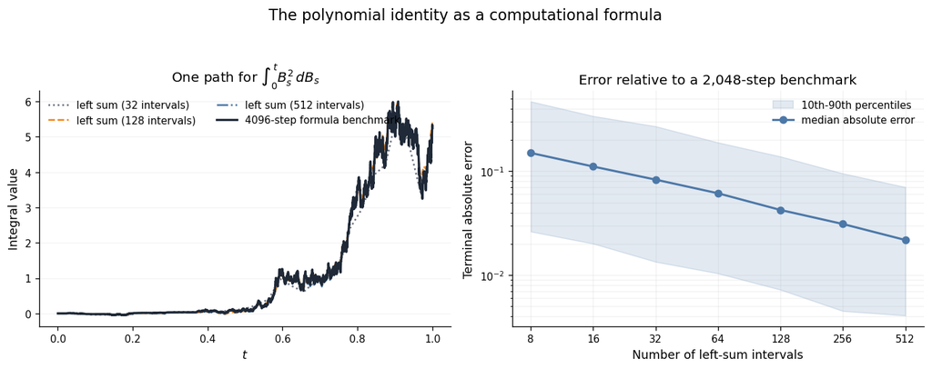

**Figure 2.** Left-point approximations to $\int_0^t B_s^2\,dB_s$ and terminal errors relative to a fine-grid formula benchmark.

Interpretation. The same Brownian path drives all curves in the left panel. Increasing the number of intervals updates $B_{t_i}^2$ more frequently, bringing the left sum toward $B_t^3/3-\int_0^t B_s\,ds$. The right panel shows the corresponding contraction across 2,500 paths. Its residual error includes both the stochastic left-sum error and the remaining trapezoidal error in the ordinary-integral benchmark.

## 3. Time-dependent Itô formula and martingales

For $f\in C^1(\mathbb R_+,C^2(\mathbb R))$, Theorem 5.4 states

$$ df(t,B_t) =\partial_x f(t,B_t)\,dB_t +\left(\partial_t f(t,B_t)+\frac{1}{2}\partial_{xx}f(t,B_t)\right)dt. $$

Remark 5.5 therefore makes $f(t,B_t)$ a local martingale when

$$ \partial_t f=-\frac{1}{2}\partial_{xx}f. $$

If additionally

$$ \mathbb E\!\left[\int_0^T \left|\partial_x f(s,B_s)\right|^2\,ds\right]<\infty, $$

it is a martingale on $[0,T]$. Example 5.6 applies this to

$$ M_t=\exp\left(\alpha B_t-\frac{\alpha^2}{2}t\right), \qquad \alpha>0, $$

for which $\mathbb E[M_t]=M_0=1$.

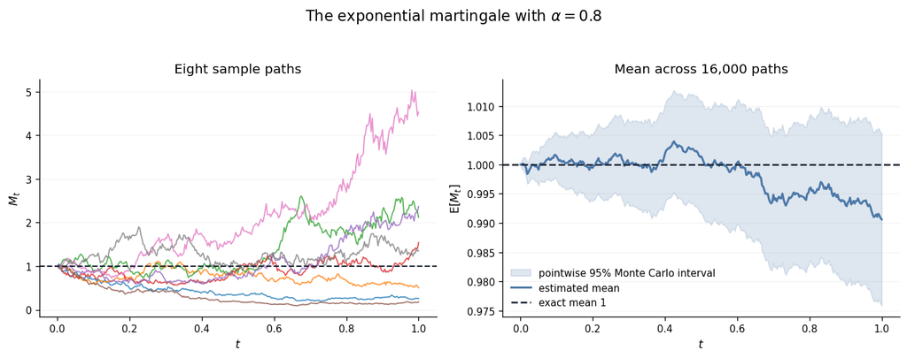

**Figure 3.** Sample paths and pointwise mean estimates for the exponential martingale with $\alpha=0.8$.

Interpretation. Individual positive paths can move far from $1$, while the ensemble mean remains close to the exact level $1$ within the displayed Monte Carlo uncertainty. A martingale is defined by conditional expectations, so this mean check is only a numerical consequence of Example 5.6, not a test of the full martingale property.

## 4. Finding martingales: an exit probability

Example 5.8 considers

$$ X_t=\sigma B_t+\mu t, \qquad \tau=\inf\{t\geq0:X_t=A\text{ or }X_t=-B\}, $$

where $A,B>0$ and, in the formula below, $\sigma>0$. A function satisfying

$$ \mu h'(x)+\frac{\sigma^2}{2}h''(x)=0, \qquad h(-B)=0,\quad h(A)=1, $$

makes the stopped process $h(X_{t\wedge\tau})$ a martingale. Hence

$$ P(X_\tau=A)=h(0), $$

where

$$ h(x)= \begin{cases} \displaystyle \frac{1-\exp\left(-2\mu(x+B)/\sigma^2\right)} {1-\exp\left(-2\mu(A+B)/\sigma^2\right)}, & \mu\neq0,\\[1.2em] \displaystyle\frac{x+B}{A+B}, & \mu=0. \end{cases} $$

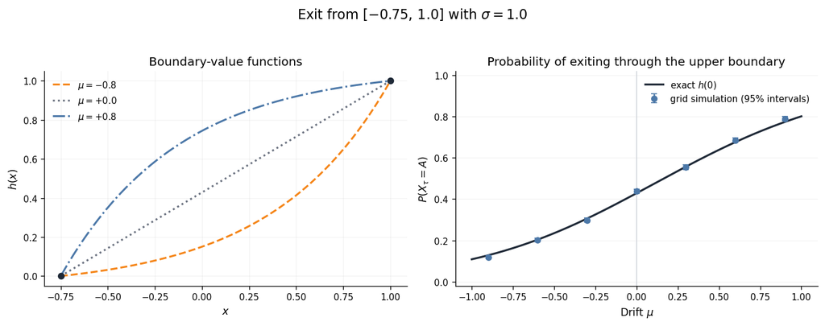

**Figure 4.** Boundary-value functions and upper-exit probabilities for $X_t=B_t+\mu t$, using 8,000 grid-simulated paths per marked drift and $\Delta t=0.0015$.

Interpretation. Each curve on the left connects the required boundary values $h(-B)=0$ and $h(A)=1$; its value at $0$ is the exact upper-exit probability. Positive drift bends the profile upward at the starting point and makes upper exit more likely. The simulated markers track the exact curve. Their intervals quantify Monte Carlo uncertainty only, while discrete monitoring contributes additional grid error.

## 5. The stochastic chain rule

A standard process in Definition 5.11 has the form

$$ X_t=X_0+\int_0^t a(s)\,ds+\int_0^t b(s)\,dB_s, $$

where $a$ and $b$ are adapted and, for every $T>0$,

$$ \int_0^T|a(s)|\,ds<\infty, \qquad \int_0^T|b(s)|^2\,ds<\infty $$

almost surely. If $g$ is adapted, $ga$ is pathwise integrable, and $gb\in L_{\mathrm{loc}}^2$, Definition 5.9 sets

$$ \int_0^T g(s)\,dX_s =\int_0^T g(s)a(s)\,ds+\int_0^T g(s)b(s)\,dB_s. $$

Theorem 5.12 states that, for $f\in C^1(\mathbb R_+,C^2(\mathbb R))$,

$$ df(t,X_t) =\partial_t f(t,X_t)\,dt +\partial_x f(t,X_t)\,dX_t +\frac{1}{2}\partial_{xx}f(t,X_t)b(t)^2\,dt. $$

The course's box calculus writes the final term using $dX_t\cdot dX_t=b(t)^2dt$. For $f(x)=x^2$,

$$ X_t^2-X_0^2 =2\int_0^t X_s a(s)\,ds +2\int_0^t X_s b(s)\,dB_s +\int_0^t b(s)^2\,ds. $$

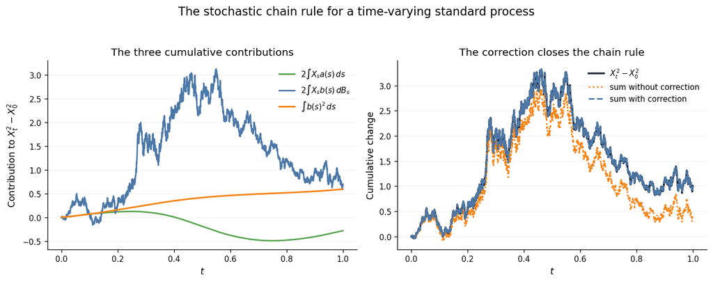

**Figure 5.** The three terms in the $x^2$ chain rule for $a(t)=0.6\cos(2\pi t)$, $b(t)=0.75+0.25\sin(2\pi t)$, and one 4,096-step path.

Interpretation. The drift and stochastic-integral terms may move in either direction, while the orange correction accumulates because $b(t)^2\geq0$. Omitting that term leaves the ordinary chain sum visibly displaced from $X_t^2-X_0^2$. Adding it produces the close finite-grid agreement predicted by Theorem 5.12; the remaining difference is discretisation error.

## 6. Quadratic variation

For a partition $P=\{0=t_0<\cdots<t_N=T\}$, Definitions 5.13 and 5.14 set

$$ \mu(P)=\max_{1\leq i\leq N}(t_i-t_{i-1}), \qquad Q_P(X)=\sum_{i=1}^N \left(X_{t_i}-X_{t_{i-1}}\right)^2. $$

If $Q_{P_n}(X)$ converges in probability to $Z_t$ for every sequence of partitions of $[0,t]$ with $\mu(P_n)\to0$, then

$$ \langle X\rangle_t=Z_t. $$

Theorem 5.15 gives, for a standard process $dX_t=a(t)\,dt+b(t)\,dB_t$,

$$ \langle X\rangle_t=\int_0^t|b(s)|^2\,ds. $$

Thus the drift has zero quadratic variation and does not change the limit. For the diffusion coefficient used in Figure 5,

$$ \int_0^1 b(t)^2\,dt =0.75^2+\frac{0.25^2}{2} =0.59375. $$

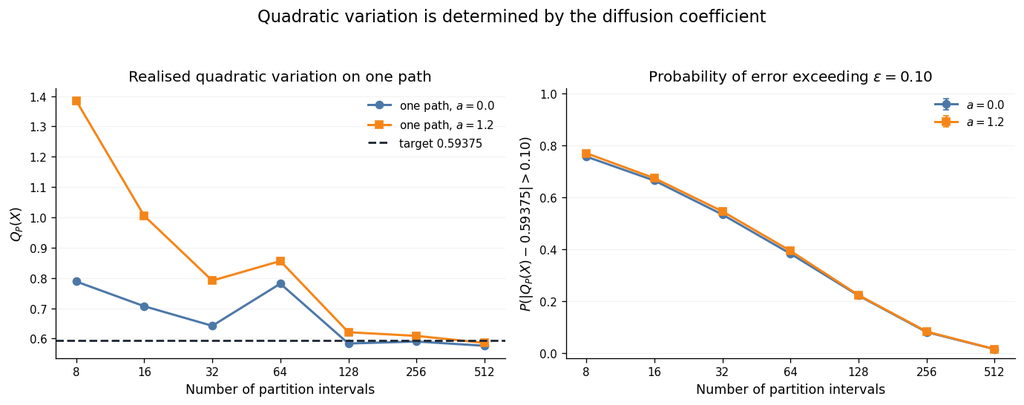

**Figure 6.** Realised quadratic variation for two processes with the same diffusion coefficient and drifts $a=0$ and $a=1.2$, with 95% Monte Carlo intervals based on 16,000 paths.

Interpretation. A single path can approach $0.59375$ irregularly, so refinement need not make every realised value move monotonically. The right panel instead uses the definition's probability question: for the fixed tolerance $0.10$, the estimated exceedance probabilities decrease for both drifts as the mesh shrinks. Theorem 5.15 identifies the common limit $\int_0^1 b(t)^2\,dt$; the simulation displays finite-partition evidence consistent with convergence in probability.